# Inwiefern beeinflusst die Anomie die Fremdenfeindlichkeit?

```r
 library("foreign")
 library(psych)
 library(devtools)
```

```r
 library(ggplot2)
 library("ggcorrplot")
 library(GPArotation)
 library(ggpubr)
 library(kableExtra)
webshot::install_phantomjs()
```

```
## It seems that the version of `phantomjs` installed is greater than or equal to the requested version.To install the requested version or downgrade to another version, use `force = TRUE`.
```

```r
library(webshot)
library(magick)
library(car)
library(plyr)
library(QuantPsyc)
```

**die Datensatz einlesen**

```r
ess<-read.spss("ESS9e02.sav",
          use.value.labels = F,
          Encoding= "UTF-8",
          to.data.frame = T
          )
```

```
## re-encoding from UTF-8
```

# Vorbreitung

**Subset für Deutschland erstellen**

```r
ess.DE<- ess[ess$cntry == "DE",]
class(ess.DE)
```

```
## [1] "data.frame"
```

```r
nrow(ess.DE)
```

```
## [1] 2358
```

```r
length(ess.DE)
```

```
## [1] 557
```

**die ausgesuchten Variablen entdecken für fremdfeindlichkeit**

- imwbcnt - Immigrants make country worse or better place to live
- imsmetn - Allow many/few immigrants of same race/ethnic group as majority
- imdfetn - Allow many/few immigrants of different race/ethnic group from majority
- impcntr - Allow many/few immigrants from poorer countries outside Europe
- imbgeco - Immigration bad or good for country’s economy
- imueclt - Country’s cultural life undermined or enriched by immigrants

```r
immgr<-c("imwbcnt","imsmetn","imdfetn", "impcntr" ,"imbgeco","imueclt")
describe(ess.DE[,immgr])
```

```
##         vars    n mean   sd median trimmed  mad min max range  skew kurtosis
## imwbcnt    1 2329 5.35 2.24      5    5.42 1.48   0  10    10 -0.22    -0.04
## imsmetn    2 2331 1.67 0.68      2    1.57 1.48   1   4     3  0.76     0.36
## imdfetn    3 2328 2.08 0.77      2    2.06 0.00   1   4     3  0.33    -0.30
## impcntr    4 2328 2.16 0.82      2    2.14 1.48   1   4     3  0.29    -0.44
## imbgeco    5 2325 6.13 2.33      6    6.26 2.97   0  10    10 -0.53    -0.03
## imueclt    6 2339 6.02 2.52      6    6.16 2.97   0  10    10 -0.44    -0.42
##           se
## imwbcnt 0.05
## imsmetn 0.01
## imdfetn 0.02
## impcntr 0.02
## imbgeco 0.05
## imueclt 0.05
```

**Recodeirung und die Variablen drehen**

```r
recode<- c("imsmetn","imdfetn" , "impcntr")


ess.DE[,recode]<-( ess.DE[,recode]*-1) #ich die Variablen gedreht
ess.DE[,recode]<- ess.DE[,recode]+ 5
ess.DE[,recode]<- ((ess.DE[,recode])-1)*10/3 #ich die Skalenneavu recodiert.

desc<-describe(ess.DE[,immgr])
descr<-desc %>%
  kbl(caption = " Quelle: ESS9-2018 ed. 3.0 ") %>%
  kable_material_dark()
descr
```

Quelle: ESS9-2018 ed. 3.0

|  | vars | n | mean | sd | median | trimmed | mad | min | max | range | skew | kurtosis | se |
| --- | --- | --- | --- | --- | --- | --- | --- | --- | --- | --- | --- | --- | --- |
| imwbcnt | 1 | 2329 | 5.347359 | 2.236835 | 5.000000 | 5.419303 | 1.4826 | 0 | 10 | 10 | -0.2160195 | -0.0374019 | 0.0463499 |
| imsmetn | 2 | 2331 | 7.782068 | 2.259929 | 6.666667 | 8.087578 | 4.9420 | 0 | 10 | 10 | -0.7577783 | 0.3625287 | 0.0468084 |
| imdfetn | 3 | 2328 | 6.391753 | 2.574549 | 6.666667 | 6.473534 | 0.0000 | 0 | 10 | 10 | -0.3274479 | -0.2969552 | 0.0533592 |
| impcntr | 4 | 2328 | 6.118270 | 2.718720 | 6.666667 | 6.208870 | 4.9420 | 0 | 10 | 10 | -0.2934137 | -0.4393479 | 0.0563473 |
| imbgeco | 5 | 2325 | 6.125161 | 2.325361 | 6.000000 | 6.259538 | 2.9652 | 0 | 10 | 10 | -0.5276011 | -0.0338689 | 0.0482257 |
| imueclt | 6 | 2339 | 6.023087 | 2.523521 | 6.000000 | 6.158569 | 2.9652 | 0 | 10 | 10 | -0.4416612 | -0.4181141 | 0.0521785 |

# PCA Anlyse für Fremdfeindlichkeit

**1-corrlation test**

```r
cor<-corr.test(ess.DE[,immgr],use = "complete")
str(corr.test(ess.DE[,immgr],use = "complete")) #signfikant
```

[output not shown]

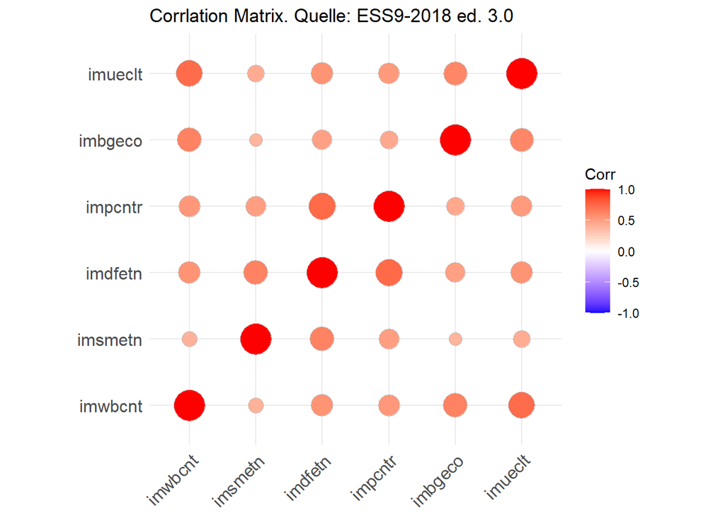

```r
cor.matrix<- cor$r
ggcorrplot(cor.matrix, method = "circle", title = "Corrlation Matrix. Quelle: ESS9-2018 ed. 3.0  ")
```

**2-lett TEST und KMO TEST**

```r
cortest.bartlett(ess.DE[,immgr])
```

```
## R was not square, finding R from data
```

```
## $chisq
## [1] 7428.555
##
## $p.value
## [1] 0
##
## $df
## [1] 15
```

```r
KMO(ess.DE[,immgr]) #MSA > 6
```

```
## Kaiser-Meyer-Olkin factor adequacy
## Call: KMO(r = ess.DE[, immgr])
## Overall MSA =  0.84
## MSA for each item =
## imwbcnt imsmetn imdfetn impcntr imbgeco imueclt
##    0.83    0.87    0.80    0.84    0.90    0.84
```

**Z Transformation**

```r
DE.immgr.z<-scale(ess.DE[,immgr])
discribe<-describe(DE.immgr.z)  # alle mean = 0
```

**3. Extraktion der Faktoren**

```r
model<- principal(DE.immgr.z, rotate = "oblimin")
model$value
```

```
## [1] 3.7234415 0.8483594 0.5124943 0.4051051 0.2692309 0.2413688
```

```r
sum(model$values)
```

```
## [1] 6
```

```r
sum(model$values>1)
```

```
## [1] 1
```

**screeplot**

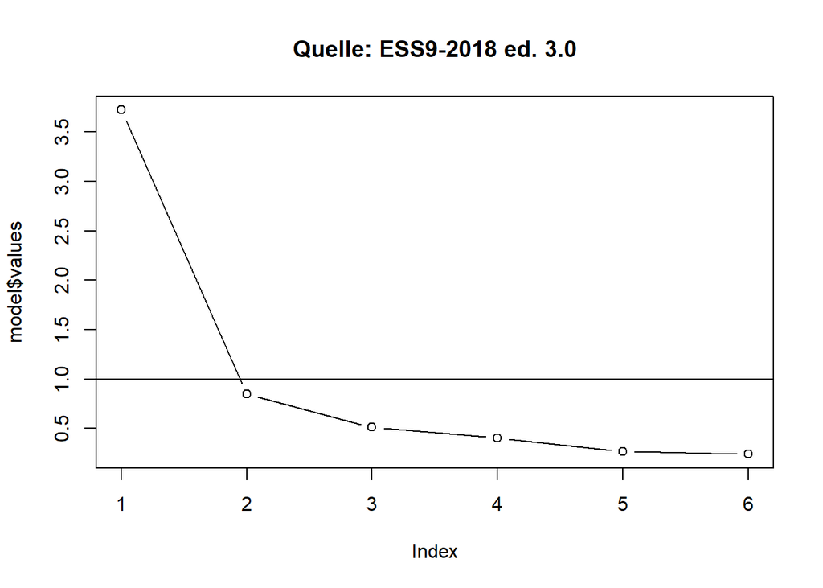

```r
plot(model$values,type = "b"  )
abline(h=1)
title("Quelle: ESS9-2018 ed. 3.0")
```

**Es soll nur 1 Faktor extrahiert werden.**

```r
model<-principal(DE.immgr.z, nfactors = 1, rotate = "oblimin")
M<-print.psych(model, cut= 0.3 , sort=T)
```

```
## Principal Components Analysis
## Call: principal(r = DE.immgr.z, nfactors = 1, rotate = "oblimin")
## Standardized loadings (pattern matrix) based upon correlation matrix
##         V  PC1   h2   u2 com
## imdfetn 3 0.84 0.71 0.29   1
## imwbcnt 1 0.82 0.67 0.33   1
## imueclt 6 0.82 0.67 0.33   1
## impcntr 4 0.79 0.63 0.37   1
## imbgeco 5 0.75 0.57 0.43   1
## imsmetn 2 0.69 0.48 0.52   1
##
##                 PC1
## SS loadings    3.72
## Proportion Var 0.62
##
## Mean item complexity =  1
## Test of the hypothesis that 1 component is sufficient.
##
## The root mean square of the residuals (RMSR) is  0.11
##  with the empirical chi square  895.03  with prob <  7.3e-187
##
## Fit based upon off diagonal values = 0.96
```

**Alpha berechnen**

```r
psych::alpha(DE.immgr.z)
```

```
## Number of categories should be increased  in order to count frequencies.
```

```
##
## Reliability analysis
## Call: psych::alpha(x = DE.immgr.z)
##
##   raw_alpha std.alpha G6(smc) average_r S/N   ase   mean   sd median_r
##       0.88      0.88    0.88      0.54 7.1 0.004 0.0013 0.79     0.53
##
##  lower alpha upper     95% confidence boundaries
## 0.87 0.88 0.88
##
##  Reliability if an item is dropped:
##         raw_alpha std.alpha G6(smc) average_r S/N alpha se  var.r med.r
## imwbcnt      0.85      0.85    0.84      0.53 5.6   0.0050 0.0109  0.51
## imsmetn      0.87      0.87    0.87      0.58 6.9   0.0042 0.0092  0.55
## imdfetn      0.84      0.84    0.83      0.52 5.4   0.0052 0.0122  0.51
## impcntr      0.85      0.85    0.85      0.54 5.9   0.0048 0.0126  0.55
## imbgeco      0.86      0.86    0.86      0.56 6.3   0.0046 0.0127  0.54
## imueclt      0.85      0.85    0.84      0.53 5.6   0.0050 0.0117  0.51
##
##  Item statistics
##            n raw.r std.r r.cor r.drop     mean sd
## imwbcnt 2329  0.81  0.81  0.78   0.72  1.5e-16  1
## imsmetn 2331  0.71  0.71  0.62   0.57 -1.7e-16  1
## imdfetn 2328  0.84  0.84  0.82   0.75 -8.4e-17  1
## impcntr 2328  0.79  0.79  0.74   0.69 -1.1e-16  1
## imbgeco 2325  0.76  0.76  0.69   0.64  5.4e-17  1
## imueclt 2339  0.81  0.81  0.78   0.72  1.6e-16  1
```

**Eine Tabelle erstellen**

```r
str(model)
```

[output not shown]

```r
model$loadings
```

```
##
## Loadings:
##         PC1
## imwbcnt 0.819
## imsmetn 0.694
## imdfetn 0.840
## impcntr 0.792
## imbgeco 0.755
## imueclt 0.817
##
##                  PC1
## SS loadings    3.723
## Proportion Var 0.621
```

```r
table<- data.frame(Variable= row.names(as.matrix(model$loadings[,1])),
                   Kompenent_1 = as.matrix(model$loading[,1]), komm = as.matrix(model$communality))

table[,1]<- c("Allow many/few immigrants of different race/ethnic group from majority",
             " Allow many/few immigrants from poorer countries outside Europe",
             "Country's cultural life undermined or enriched by immigrants",
               " Allow many/few immigrants from poorer countries outside Europe",
             "Immigration bad or good for country's economy",
             "Allow many/few immigrants of same race/ethnic group as majority")

tb<-table %>%
  kbl(caption = " Quelle: ESS9-2018 ed. 3.0") %>%
  kable_material_dark()
tb
```

Quelle: ESS9-2018 ed. 3.0

[output not shown]

```r
save_kable(tb, "./table.png")
```

**indexbildung**

```r
which(names(ess.DE)%in% c("imwbcnt","imsmetn","imdfetn", "impcntr" ,"imbgeco","imueclt" ))
```

```
## [1] 105 106 107 108 109 110
```

```r
ess.DE$fremdhate<- rowMeans(ess.DE[,c(108, 109, 110,105, 106 ,107)])
table(is.na(ess.DE$fremdhate))
```

```
##
## FALSE  TRUE
##  2264    94
```

**2264 sind gültig , 94 sind NA**

**die Beschreibung von der Index**

```r
index<-describe(ess.DE$fremdhate)
ind<-index %>%
  kbl() %>%
  kable_material_dark()
save_kable( ind, "./index.png")
ind
```

|  | vars | n | mean | sd | median | trimmed | mad | min | max | range | skew | kurtosis | se |
| --- | --- | --- | --- | --- | --- | --- | --- | --- | --- | --- | --- | --- | --- |
| X1 | 1 | 2264 | 6.296771 | 1.925235 | 6.388889 | 6.383033 | 1.894433 | 0 | 10 | 10 | -0.420029 | -0.0194614 | 0.0404618 |

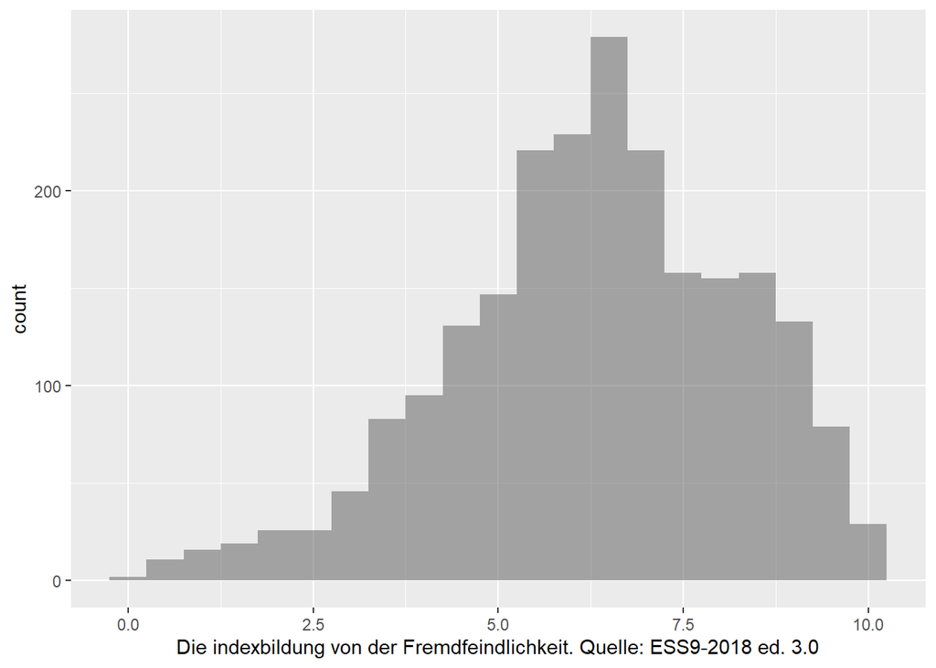

```r
ggplot( ess.DE, aes(x=fremdhate)) +
    geom_histogram(binwidth=0.5, alpha=0.5, position="identity") +
xlab("Die indexbildung von der Fremdfeindlichkeit. Quelle: ESS9-2018 ed. 3.0")
```

**die Beschreibung von die ausgewälten Variablen**

```r
which(names(ess.DE)%in% c("ppltrst", "pplfair" , "pplhlp", "psppsgva","psppipla","cptppola","ifrjob","iprspot","iplyfr",
                         "sclmeet", "inprdsc","sclact","happy"))
```

```
##  [1]  10  11  12  14  16  17 111 112 113 114 488 533
```

```r
col<-c(10,11,12,14, 16, 17,111,112,113,114,488,533)
d<-describe(ess.DE[,col])

dd<-d %>%
  kbl(caption = "Quelle: ESS9-2018 ed. 3.0") %>%
  kable_material_dark()
dd
```

Quelle: ESS9-2018 ed. 3.0

|  | vars | n | mean | sd | median | trimmed | mad | min | max | range | skew | kurtosis | se |
| --- | --- | --- | --- | --- | --- | --- | --- | --- | --- | --- | --- | --- | --- |
| ppltrst | 1 | 2358 | 5.400339 | 2.2220860 | 6 | 5.536017 | 1.4826 | 0 | 10 | 10 | -0.4391207 | -0.2172114 | 0.0457603 |
| pplfair | 2 | 2357 | 6.184981 | 2.0657022 | 7 | 6.287228 | 1.4826 | 0 | 10 | 10 | -0.5191534 | 0.0671215 | 0.0425489 |
| pplhlp | 3 | 2355 | 5.443737 | 2.0214751 | 5 | 5.490716 | 2.9652 | 0 | 10 | 10 | -0.1937996 | -0.1452233 | 0.0416556 |
| psppsgva | 4 | 2339 | 2.492091 | 0.9268829 | 2 | 2.477843 | 1.4826 | 1 | 5 | 4 | 0.1294130 | -0.5294402 | 0.0191650 |
| psppipla | 5 | 2344 | 2.498293 | 0.9252915 | 2 | 2.482409 | 1.4826 | 1 | 5 | 4 | 0.1439316 | -0.4424937 | 0.0191117 |
| cptppola | 6 | 2340 | 2.789316 | 1.0459991 | 3 | 2.775641 | 1.4826 | 1 | 5 | 4 | 0.2645211 | -0.4747046 | 0.0216234 |
| happy | 7 | 2355 | 7.818259 | 1.6988945 | 8 | 8.018037 | 1.4826 | 0 | 10 | 10 | -1.2899266 | 2.3833229 | 0.0350083 |
| sclmeet | 8 | 2356 | 4.853141 | 1.3895556 | 5 | 4.931071 | 1.4826 | 1 | 7 | 6 | -0.4988174 | -0.3323185 | 0.0286278 |
| inprdsc | 9 | 2358 | 3.601781 | 1.2568138 | 4 | 3.620233 | 1.4826 | 0 | 6 | 6 | -0.2863163 | 0.1091564 | 0.0258821 |
| sclact | 10 | 2348 | 2.742760 | 0.9451572 | 3 | 2.765426 | 1.4826 | 1 | 5 | 4 | 0.0383248 | -0.4193814 | 0.0195054 |
| ifrjob | 11 | 2280 | 6.986842 | 2.8716591 | 8 | 7.394737 | 2.9652 | 0 | 10 | 10 | -0.9643957 | 0.0822822 | 0.0601403 |
| iprspot | 12 | 2321 | 3.501939 | 1.3294154 | 3 | 3.507270 | 1.4826 | 1 | 6 | 5 | 0.0068355 | -0.9816062 | 0.0275945 |

**recodieren und Z.transformation**

```r
ess.DE[,c(14, 16, 17)]<-(ess.DE[,c(14, 16, 17)]-1)*10/4
ess.DE[,"iprspot"]<- ess.DE[,"iprspot"]*10/6
ess.DE[,"sclact"]<- ess.DE[,"sclact"]*10/5
ess.DE[,"inprdsc"]<- ess.DE[,"inprdsc"]*10/6
ess.DE[,"sclmeet"]<- ess.DE[,"sclmeet"]*10/7

describe(ess.DE[,col])
```

```
##          vars    n mean   sd median trimmed  mad  min max range  skew kurtosis
## ppltrst     1 2358 5.40 2.22   6.00    5.54 1.48 0.00  10 10.00 -0.44    -0.22
## pplfair     2 2357 6.18 2.07   7.00    6.29 1.48 0.00  10 10.00 -0.52     0.07
## pplhlp      3 2355 5.44 2.02   5.00    5.49 2.97 0.00  10 10.00 -0.19    -0.15
## psppsgva    4 2339 3.73 2.32   2.50    3.69 3.71 0.00  10 10.00  0.13    -0.53
## psppipla    5 2344 3.75 2.31   2.50    3.71 3.71 0.00  10 10.00  0.14    -0.44
## cptppola    6 2340 4.47 2.61   5.00    4.44 3.71 0.00  10 10.00  0.26    -0.47
## happy       7 2355 7.82 1.70   8.00    8.02 1.48 0.00  10 10.00 -1.29     2.38
## sclmeet     8 2356 6.93 1.99   7.14    7.04 2.12 1.43  10  8.57 -0.50    -0.33
## inprdsc     9 2358 6.00 2.09   6.67    6.03 2.47 0.00  10 10.00 -0.29     0.11
## sclact     10 2348 5.49 1.89   6.00    5.53 2.97 2.00  10  8.00  0.04    -0.42
## ifrjob     11 2280 6.99 2.87   8.00    7.39 2.97 0.00  10 10.00 -0.96     0.08
## iprspot    12 2321 5.84 2.22   5.00    5.85 2.47 1.67  10  8.33  0.01    -0.98
##            se
## ppltrst  0.05
## pplfair  0.04
## pplhlp   0.04
## psppsgva 0.05
## psppipla 0.05
## cptppola 0.05
## happy    0.04
## sclmeet  0.04
## inprdsc  0.04
## sclact   0.04
## ifrjob   0.06
## iprspot  0.05
```

```r
anomia.z<-scale( ess.DE[,col])
describe(anomia.z)
```

```
##          vars    n mean sd median trimmed  mad   min  max range  skew kurtosis
## ppltrst     1 2358    0  1   0.27    0.06 0.67 -2.43 2.07  4.50 -0.44    -0.22
## pplfair     2 2357    0  1   0.39    0.05 0.72 -2.99 1.85  4.84 -0.52     0.07
## pplhlp      3 2355    0  1  -0.22    0.02 1.47 -2.69 2.25  4.95 -0.19    -0.15
## psppsgva    4 2339    0  1  -0.53   -0.02 1.60 -1.61 2.71  4.32  0.13    -0.53
## psppipla    5 2344    0  1  -0.54   -0.02 1.60 -1.62 2.70  4.32  0.14    -0.44
## cptppola    6 2340    0  1   0.20   -0.01 1.42 -1.71 2.11  3.82  0.26    -0.47
## happy       7 2355    0  1   0.11    0.12 0.87 -4.60 1.28  5.89 -1.29     2.38
## sclmeet     8 2356    0  1   0.11    0.06 1.07 -2.77 1.54  4.32 -0.50    -0.33
## inprdsc     9 2358    0  1   0.32    0.01 1.18 -2.87 1.91  4.77 -0.29     0.11
## sclact     10 2348    0  1   0.27    0.02 1.57 -1.84 2.39  4.23  0.04    -0.42
## ifrjob     11 2280    0  1   0.35    0.14 1.03 -2.43 1.05  3.48 -0.96     0.08
## iprspot    12 2321    0  1  -0.38    0.00 1.12 -1.88 1.88  3.76  0.01    -0.98
##            se
## ppltrst  0.02
## pplfair  0.02
## pplhlp   0.02
## psppsgva 0.02
## psppipla 0.02
## cptppola 0.02
## happy    0.02
## sclmeet  0.02
## inprdsc  0.02
## sclact   0.02
## ifrjob   0.02
## iprspot  0.02
```